# Testing a very basic function in R

# Required libraries

```r
library(RPostgreSQL)
library(tidyverse)
library(dbplyr)
library(rjson)
library(DBI)
library(lubridate)
library(tibble)
library(olsrr)
library(ggplot2)
library(ggExtra)
library(gridExtra)
```

# Get the auxiliary data

```r
source("get_HMRC_aux_data.R")
list1 <- get_HMRC_aux_data()
comcode <- data.frame(Reduce(rbind, list1[1]))
port    <- data.frame(Reduce(rbind, list1[2]))
country <- data.frame(Reduce(rbind, list1[3]))
write.csv(comcode,file="comcode.csv")
write.csv(country,file="country.csv")
```

# Find the comcodes for

- Chicken
- Beef
- Cucumbers (watch out, beacuse there are *sea cucumbers*!)

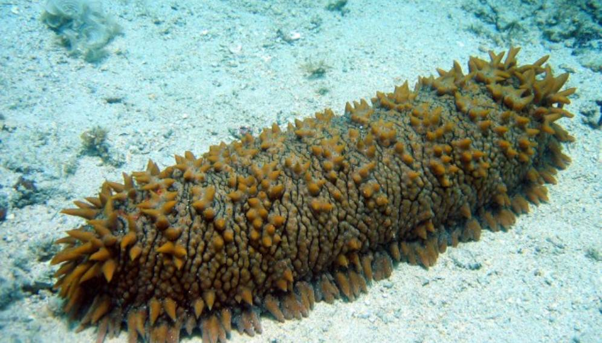

A sea cucumber in all its glory. This creature kills hundreds of people every year.

```r
cc_chicken      <- comcode[grep('CHICKEN',   toupper(comcode$description)),]
cc_all_cucumber <- comcode[grep('CUCUMBER',  toupper(comcode$description)),]
#cc_cucumber     <- cc_all_cucumber[grep('VEGETABLES',toupper(cc_all_cucumber$description)),]
cc_beef         <- comcode[grep('BEEF',      toupper(comcode$description)),]
```

# This is Warren’s magic with a little bit of extra work

## Is ten minutes too long? Then load the csv files written at the end of this notebook

```r
source("get_Comtrade_data.R")
stime <- Sys.time()
polish_chicken   <- get_Comtrade_data(201001,201601,"default","02071","616")
spanish_cucumber <- get_Comtrade_data(201001,201601,"default","070700","724")
brazilian_beef   <- get_Comtrade_data(201001,201601,"default","160250","76")
etime <- Sys.time()
(etime-stime)
```

```
Time difference of 7.412256 mins
```

# Removing irrelevant variables (columns)

```r
polish_chicken   <- polish_chicken   %>% select(-reporter_code,-partner,-partner_code)
spanish_cucumber <- spanish_cucumber %>% select(-reporter_code,-partner,-partner_code)
brazilian_beef   <- brazilian_beef   %>% select(-reporter_code,-partner,-partner_code)
```

# In case the same ‘product’ comes under several commodity codes, add them together:

## For instance: different chicken cuts have different commodity codes.

```r
polish_chicken   <- polish_chicken %>%
                    group_by(trade_flow,reporter,period) %>%
                    summarize(net_weight_kg   = sum(netweight_kg),
                              trade_value_usd = sum(trade_value_usd)) %>% ungroup()
spanish_cucumber <- spanish_cucumber %>%
                    group_by(trade_flow,reporter,period) %>%
                    summarize(net_weight_kg   = sum(netweight_kg),
                              trade_value_usd = sum(trade_value_usd)) %>% ungroup()
brazilian_beef   <- brazilian_beef %>%
                    group_by(trade_flow,reporter,period) %>%
                    summarize(net_weight_kg   = sum(netweight_kg),
                              trade_value_usd = sum(trade_value_usd)) %>% ungroup()
```

# Get the price in usd per kilogram

```r
polish_chicken   <- polish_chicken   %>% mutate(price_usd_kg = trade_value_usd/net_weight_kg)
spanish_cucumber <- spanish_cucumber %>% mutate(price_usd_kg = trade_value_usd/net_weight_kg)
brazilian_beef   <- brazilian_beef   %>% mutate(price_usd_kg = trade_value_usd/net_weight_kg)
```

# Refurbish the date into something R understand

```r
polish_chicken   <- polish_chicken %>%
                    mutate(period_date = ymd(paste(period,"01",sep="")))
spanish_cucumber <- spanish_cucumber %>%
                    mutate(period_date = ymd(paste(period,"01",sep="")))
brazilian_beef   <- brazilian_beef %>%
                    mutate(period_date = ymd(paste(period,"01",sep="")))
```

# Clean the data by removing incomplete cases

# Use simpler nomenclature for each data frame

```r
polc <- polish_chicken[complete.cases(polish_chicken),]
spac <- spanish_cucumber[complete.cases(spanish_cucumber),]
brab <- brazilian_beef[complete.cases(brazilian_beef),]
```

# Restrict data to imports

```r
polci <- polc %>% filter(trade_flow=="Imports")
spaci <- spac %>% filter(trade_flow=="Imports")
brabi <- brab %>% filter(trade_flow=="Imports")
```

# Searching for outstanding values

## In box plots, the line in the blox represent the median of the data.

## The box spans over the IQR, i.e. the 25 and 75% percentiles.

## Outliers are located at distanced larger than 1.5 IQR and are represented by dots.

*Why do we need the bloxplots of the new weight and trade value (extensive magnitudes)? Erase them…* The boxplot of the price shows are relatively homogeneity in prices for polish chicken *The opposite is true for the brazilian beef with many huge outliers* Spanish cucumbers are somehow in between these two extremes *The most imported food (total net weight) is the spanish cucumber* … followed by the polish chicken and brazilian beef

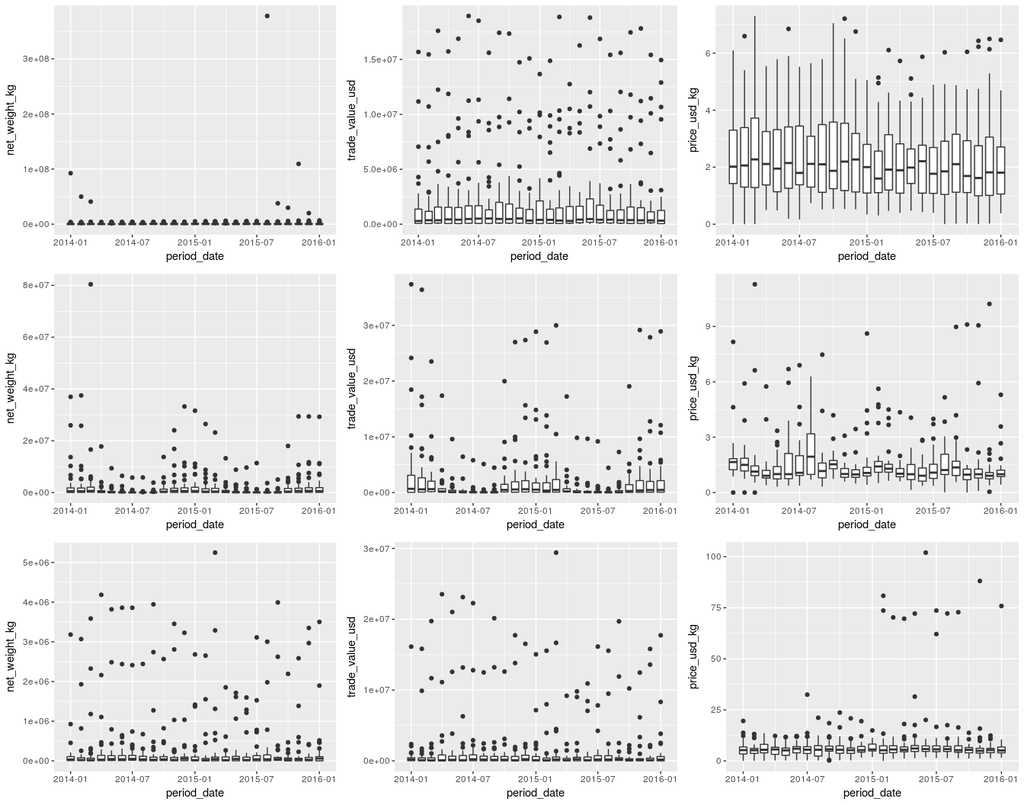

```r
tmp <- polci
p1 <- ggplot(data=tmp) +
  geom_boxplot(mapping = aes(x=period_date,y=net_weight_kg,group=period_date))
p2 <- ggplot(data=tmp) +
  geom_boxplot(mapping = aes(x=period_date,y=trade_value_usd,group=period_date))
p3 <- ggplot(data=tmp) +
  geom_boxplot(mapping = aes(x=period_date,y=price_usd_kg,group=period_date))
tmp <- spaci
p4 <- ggplot(data=tmp) +
  geom_boxplot(mapping = aes(x=period_date,y=net_weight_kg,group=period_date))
p5 <- ggplot(data=tmp) +
  geom_boxplot(mapping = aes(x=period_date,y=trade_value_usd,group=period_date))
p6 <- ggplot(data=tmp) +
  geom_boxplot(mapping = aes(x=period_date,y=price_usd_kg,group=period_date))
tmp <- brabi
p7 <- ggplot(data=tmp) +
  geom_boxplot(mapping = aes(x=period_date,y=net_weight_kg,group=period_date))
p8 <- ggplot(data=tmp) +
  geom_boxplot(mapping = aes(x=period_date,y=trade_value_usd,group=period_date))
p9 <- ggplot(data=tmp) +
  geom_boxplot(mapping = aes(x=period_date,y=price_usd_kg,group=period_date))
grid.arrange(p1,p2,p3,p4,p5,p6,p7,p8,p9,ncol=3,nrow=3)
```

# Get plots comparing prices between UK and World

## These plots are almost identical but provide additional information

## The red dots in the boxplot correspond to UK data

*Many outliers correspond to countries with elevated transport costs* This includes Finland, Greenland, French polynesia, Iceland, Cyprus *Also, several middle east countries: Qatar, Kuwait #*No seasonality in the price (although clear in net weight and trade value) #*UK pays more for the polish chicken but the same for spanish cucumbers and brazilian beef

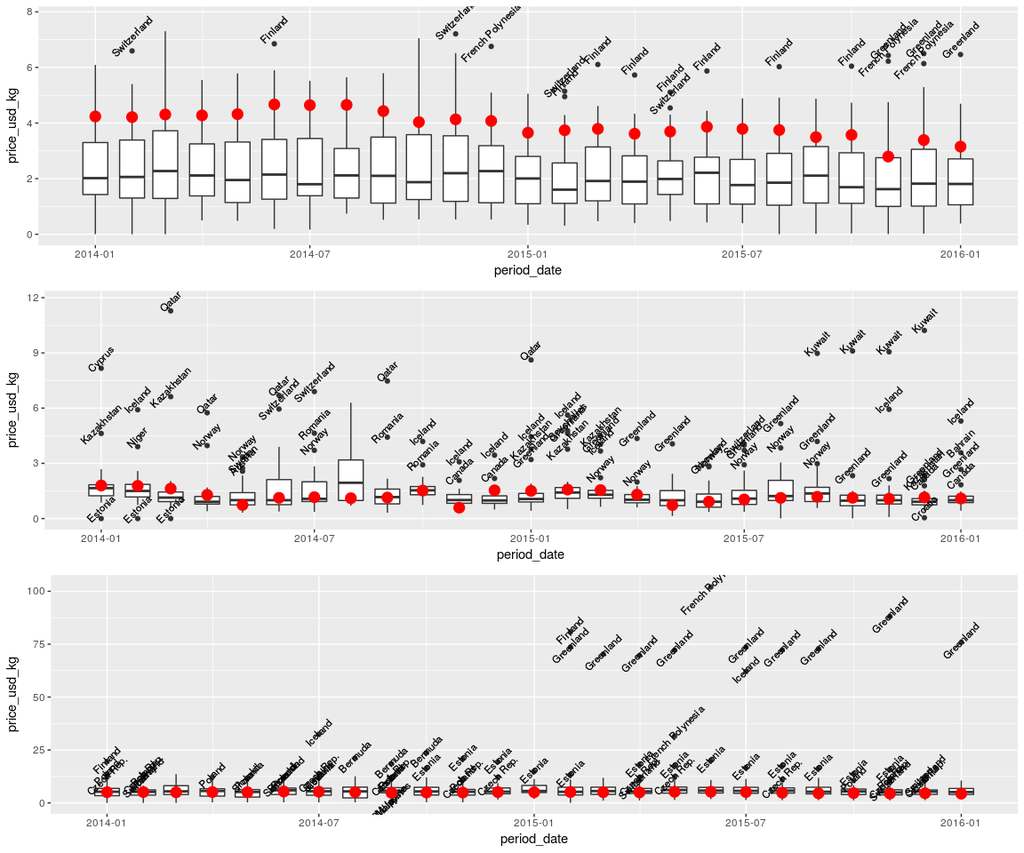

# Another look at the influence measures (outliers and leverag points)

```r
par(mfrow=c(3,2))
tmp <- polci
fitdata <- lm(trade_value_usd ~ net_weight_kg,tmp)
infl <- influence.measures(fitdata)
caca <- which(apply(infl$is.inf, 1, any))
cc <- tmp[caca,]
plot(data=tmp,trade_value_usd ~ net_weight_kg,cex=0.5,pch=19,xlab='')
points(data=cc,trade_value_usd ~ net_weight_kg,cex=0.5,pch=19,col="red")
```

```r
tmp2 <- tmp[-caca,]
fitdata2 <- lm(trade_value_usd ~ net_weight_kg,tmp2)
abline(fitdata,col="red")
plot(data=tmp2,trade_value_usd ~ net_weight_kg,cex=0.5,pch=19,xlab='',ylab='')
```

```r
abline(fitdata2)
#
tmp <- spaci
fitdata <- lm(trade_value_usd ~ net_weight_kg,tmp)
infl <- influence.measures(fitdata)
caca <- which(apply(infl$is.inf, 1, any))
cc <- tmp[caca,]
plot(data=tmp,trade_value_usd ~ net_weight_kg,cex=0.5,pch=19,xlab='')
```

```r
points(data=cc,trade_value_usd ~ net_weight_kg,cex=0.5,pch=19,col="red")
tmp2 <- tmp[-caca,]
fitdata2 <- lm(trade_value_usd ~ net_weight_kg,tmp2)
abline(fitdata,col="red")
```

```r
plot(data=tmp2,trade_value_usd ~ net_weight_kg,cex=0.5,pch=19,xlab='',ylab='')
abline(fitdata2)
```

```r
#
tmp <- brabi
fitdata <- lm(trade_value_usd ~ net_weight_kg,tmp)
infl <- influence.measures(fitdata)
caca <- which(apply(infl$is.inf, 1, any))
cc <- tmp[caca,]
plot(data=tmp,trade_value_usd ~ net_weight_kg,cex=0.5,pch=19)
points(data=cc,trade_value_usd ~ net_weight_kg,cex=0.5,pch=19,col="red")
```

```r
tmp2 <- tmp[-caca,]
fitdata2 <- lm(trade_value_usd ~ net_weight_kg,tmp2)
abline(fitdata,col="red")
plot(data=tmp2,trade_value_usd ~ net_weight_kg,cex=0.5,pch=19,ylab='')
```

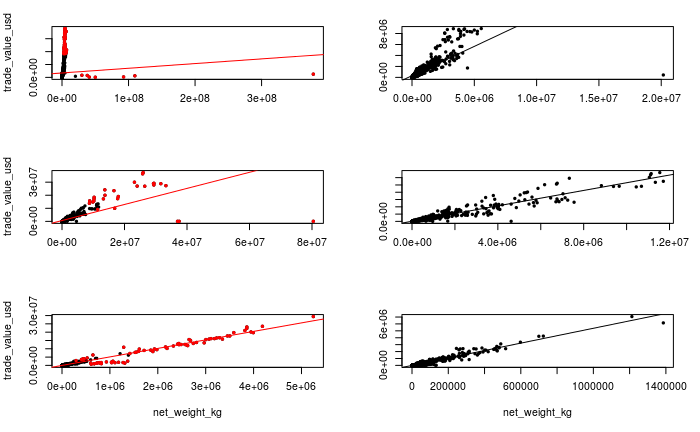

```r
abline(fitdata2)
```

# Temporal evolution of the UK trade

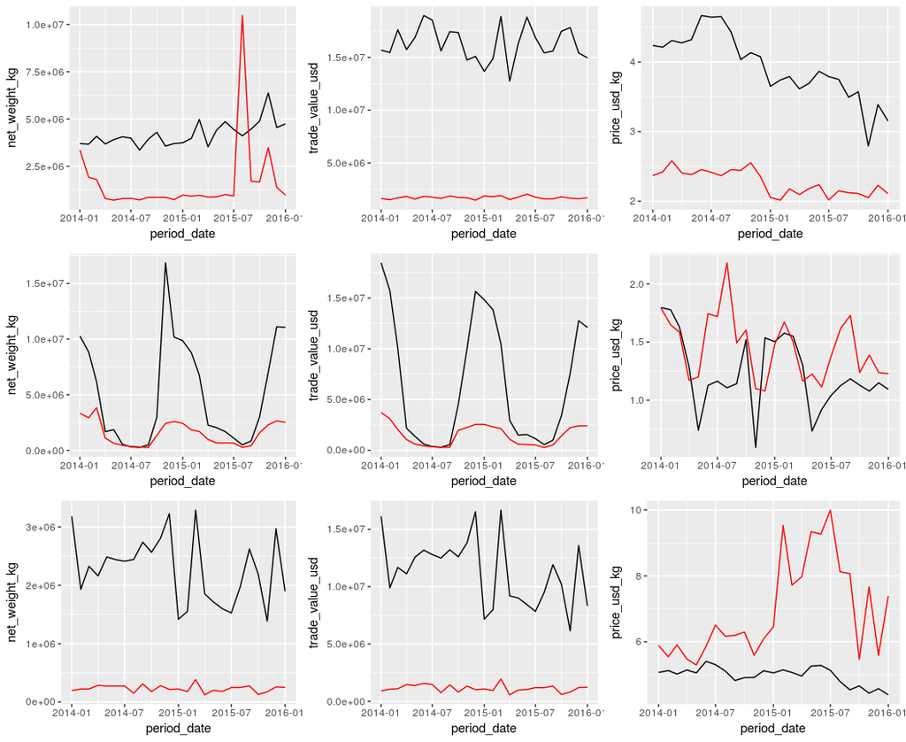

```r
tmp <- polci
p1 <- ggplot(data=tmp %>%
         filter(reporter=="United Kingdom"),aes(x=period_date,y=net_weight_kg)) + geom_line() +
         geom_line(data=tmp %>% group_by(period_date) %>% summarize(caca=mean(net_weight_kg)),
                   aes(x=period_date,y=caca),color="red")
p2 <- ggplot(data=tmp %>%
         filter(reporter=="United Kingdom"),aes(x=period_date,y=trade_value_usd)) + geom_line() +
         geom_line(data=tmp %>% group_by(period_date) %>% summarize(caca=mean(trade_value_usd)),
                   aes(x=period_date,y=caca),color="red")
p3 <- ggplot(data=tmp %>%
         filter(reporter=="United Kingdom"),aes(x=period_date,y=price_usd_kg)) + geom_line() +
         geom_line(data=tmp %>% group_by(period_date) %>% summarize(caca=mean(price_usd_kg)),
                   aes(x=period_date,y=caca),color="red")
#
tmp <- spaci
p4 <- ggplot(data=tmp %>%
         filter(reporter=="United Kingdom"),aes(x=period_date,y=net_weight_kg)) + geom_line() +
         geom_line(data=tmp %>% group_by(period_date) %>% summarize(caca=mean(net_weight_kg)),
                   aes(x=period_date,y=caca),color="red")
p5 <- ggplot(data=tmp %>%
         filter(reporter=="United Kingdom"),aes(x=period_date,y=trade_value_usd)) + geom_line() +
         geom_line(data=tmp %>% group_by(period_date) %>% summarize(caca=mean(trade_value_usd)),
                   aes(x=period_date,y=caca),color="red")
p6 <- ggplot(data=tmp %>%
         filter(reporter=="United Kingdom"),aes(x=period_date,y=price_usd_kg)) + geom_line() +
         geom_line(data=tmp %>% group_by(period_date) %>% summarize(caca=mean(price_usd_kg)),
                   aes(x=period_date,y=caca),color="red")
#
tmp <- brabi
p7 <- ggplot(data=tmp %>%
         filter(reporter=="United Kingdom"),aes(x=period_date,y=net_weight_kg)) + geom_line() +
         geom_line(data=tmp %>% group_by(period_date) %>% summarize(caca=mean(net_weight_kg)),
                   aes(x=period_date,y=caca),color="red")
p8 <- ggplot(data=tmp %>%
         filter(reporter=="United Kingdom"),aes(x=period_date,y=trade_value_usd)) + geom_line() +
         geom_line(data=tmp %>% group_by(period_date) %>% summarize(caca=mean(trade_value_usd)),
                   aes(x=period_date,y=caca),color="red")
p9 <- ggplot(data=tmp %>%
         filter(reporter=="United Kingdom"),aes(x=period_date,y=price_usd_kg)) + geom_line() +
         geom_line(data=tmp %>% group_by(period_date) %>% summarize(caca=mean(price_usd_kg)),
                   aes(x=period_date,y=caca),color="red")
grid.arrange(p1,p2,p3,p4,p5,p6,p7,p8,p9,ncol=3,nrow=3)
```